# Decoding Household Debt. Exploring Key Predictors and Model Comparisons Using Machine Learning Techniques.

Michael-Lee, W., Success A., Stephen B., Chris H. Stephen, A.

2025-02-19

# Introduction

This research seeks to identify the key demographic and financial predictors of high household debt by leveraging models such as Linear Discriminant Analysis (LDA), Quadratic Discriminant Analysis (QDA) decision trees, and Random Forests. The overarching research question is:

“Which demographic and financial factors are the most significant predictors of household debt levels, and how do Linear Discriminant Analysis, Quadratic Discriminant Analysis, and Random Forest models compare in predicting these outcomes?”

This research can benefit various sectors, such as: Banks and Lenders, Government and Policymakers, Debt Counselling Services, etc

The **dataset** was obtained from the Federal Reserve System of the Central Bank of the United States and is publicly available for use at https://www.federalreserve.gov/econres/scfindex.htm. It is in CSV format and contains financial and demographic information from the 2022 Survey of Consumer Finances (SCF), which surveys over 4,000 U.S. households.

The data includes variables such as: • Financial Information: Debt, investments, pensions, and income. • Demographic Information: Age, sex, marital status, and education level.

The dependent variable will be total household debt, which will be categorised as follows: • 1 (High Debt): Debt levels above a specific threshold (i.e. the median). • 0 (Not High Debt): Debt levels below the defined threshold.

Demographic and financial predictors was selected based on historical research and literature review (see predictors selected in the relevant section in the code below).

# Data Import, Wrangling and Cleaning

## Loading required libraries

```r
library(dplyr)
library(ggplot2)
library(tidyr)
library(corrplot)
library(caret)
library(randomForest)
library(car)
library(biotools)  # For Box's M Test
library(MASS)  # For LDA/QDA
library(pROC)  # For ROC Curve
```

```r
# Read the dataset
SCF = read.csv("SCFP2022.csv")

# Create cleaned dataset with selected variables
SCF_clean = SCF %>%
  dplyr::select(c("DEBT", "INCOME", "ASSET", "CCBAL", "CANTMANG", "LATE",
                  "FORECLLAST5", "BNKRUPLAST5", "MARRIED", "AGE", "EDUC",
                  "FINLIT", "BPLANCJ", "HHSEX", "OCCAT2"))

# Extract every 5th row (sampling technique)
row_indices1 <- seq(1, nrow(SCF_clean), by = 5)
data1 <- SCF_clean[row_indices1, ]
```

## Creating Binary Debt Classification

```r
# Calculate median debt
median_debt = median(data1$DEBT, na.rm = TRUE)

# Create binary debt classification
data1$DEBT_CLASS = ifelse(data1$DEBT > median_debt, "High", "Low")
data1$DEBT_CLASS = factor(data1$DEBT_CLASS, levels = c("Low", "High"))

# Create summary of debt classification
debt_summary = table(data1$DEBT_CLASS)
print("Distribution of Debt Classification:")
```

```
## [1] "Distribution of Debt Classification:"
```

```r
print(debt_summary)
```

```
##
##  Low High
## 2303 2292
```

## Summary stats for features in the dataset.

```r
summary(data1) # print the summary stats
```

```
##       DEBT               INCOME              ASSET               CCBAL
##  Min.   :        0   Min.   :        0   Min.   :0.000e+00   Min.   :     0
##  1st Qu.:        0   1st Qu.:    42156   1st Qu.:6.299e+04   1st Qu.:     0
##  Median :    29000   Median :    94039   Median :5.424e+05   Median :     0
##  Mean   :   365329   Mean   :  1593197   Mean   :2.013e+07   Mean   :  2515
##  3rd Qu.:   216275   3rd Qu.:   264823   3rd Qu.:2.718e+06   3rd Qu.:  1200
##  Max.   :123890000   Max.   :453258755   Max.   :2.178e+09   Max.   :139000
##     CANTMANG      LATE         FORECLLAST5      BNKRUPLAST5        MARRIED
##  Min.   :0   Min.   :0.0000   Min.   :0.0000   Min.   :0.0000   Min.   :1.000
##  1st Qu.:0   1st Qu.:0.0000   1st Qu.:0.0000   1st Qu.:0.0000   1st Qu.:1.000
##  Median :0   Median :0.0000   Median :0.0000   Median :0.0000   Median :1.000
##  Mean   :0   Mean   :0.1134   Mean   :0.0037   Mean   :0.0111   Mean   :1.368
##  3rd Qu.:0   3rd Qu.:0.0000   3rd Qu.:0.0000   3rd Qu.:0.0000   3rd Qu.:2.000
##  Max.   :0   Max.   :1.0000   Max.   :1.0000   Max.   :1.0000   Max.   :2.000
##       AGE             EDUC           FINLIT         BPLANCJ
##  Min.   :18.00   Min.   :-1.00   Min.   :0.000   Min.   :0.00000
##  1st Qu.:42.00   1st Qu.: 8.00   1st Qu.:2.000   1st Qu.:0.00000
##  Median :56.00   Median :11.00   Median :3.000   Median :0.00000
##  Mean   :54.47   Mean   :10.33   Mean   :2.304   Mean   :0.09097
##  3rd Qu.:67.00   3rd Qu.:12.00   3rd Qu.:3.000   3rd Qu.:0.00000
##  Max.   :95.00   Max.   :14.00   Max.   :3.000   Max.   :1.00000
##      HHSEX           OCCAT2      DEBT_CLASS
##  Min.   :1.000   Min.   :1.000   Low :2303
##  1st Qu.:1.000   1st Qu.:1.000   High:2292
##  Median :1.000   Median :2.000
##  Mean   :1.239   Mean   :2.302
##  3rd Qu.:1.000   3rd Qu.:4.000
##  Max.   :2.000   Max.   :4.000
```

# Exploratory Data Analysis

## Summary Stats for Numerical Variables

Zoom in on numeric features to understand nature of the variables and possible relationships.

```r
# Summary statistics for key numerical variables
num_vars = c("DEBT", "INCOME", "ASSET", "CCBAL", "AGE", "EDUC", "FINLIT")
summary_stats = summary(data1[num_vars])
print("Summary Statistics:")
```

```
## [1] "Summary Statistics:"
```

```r
print(summary_stats)
```

```
##       DEBT               INCOME              ASSET               CCBAL
##  Min.   :        0   Min.   :        0   Min.   :0.000e+00   Min.   :     0
##  1st Qu.:        0   1st Qu.:    42156   1st Qu.:6.299e+04   1st Qu.:     0
##  Median :    29000   Median :    94039   Median :5.424e+05   Median :     0
##  Mean   :   365329   Mean   :  1593197   Mean   :2.013e+07   Mean   :  2515
##  3rd Qu.:   216275   3rd Qu.:   264823   3rd Qu.:2.718e+06   3rd Qu.:  1200
##  Max.   :123890000   Max.   :453258755   Max.   :2.178e+09   Max.   :139000
##       AGE             EDUC           FINLIT
##  Min.   :18.00   Min.   :-1.00   Min.   :0.000
##  1st Qu.:42.00   1st Qu.: 8.00   1st Qu.:2.000
##  Median :56.00   Median :11.00   Median :3.000
##  Mean   :54.47   Mean   :10.33   Mean   :2.304
##  3rd Qu.:67.00   3rd Qu.:12.00   3rd Qu.:3.000
##  Max.   :95.00   Max.   :14.00   Max.   :3.000
```

Plot the distribution of the variables.

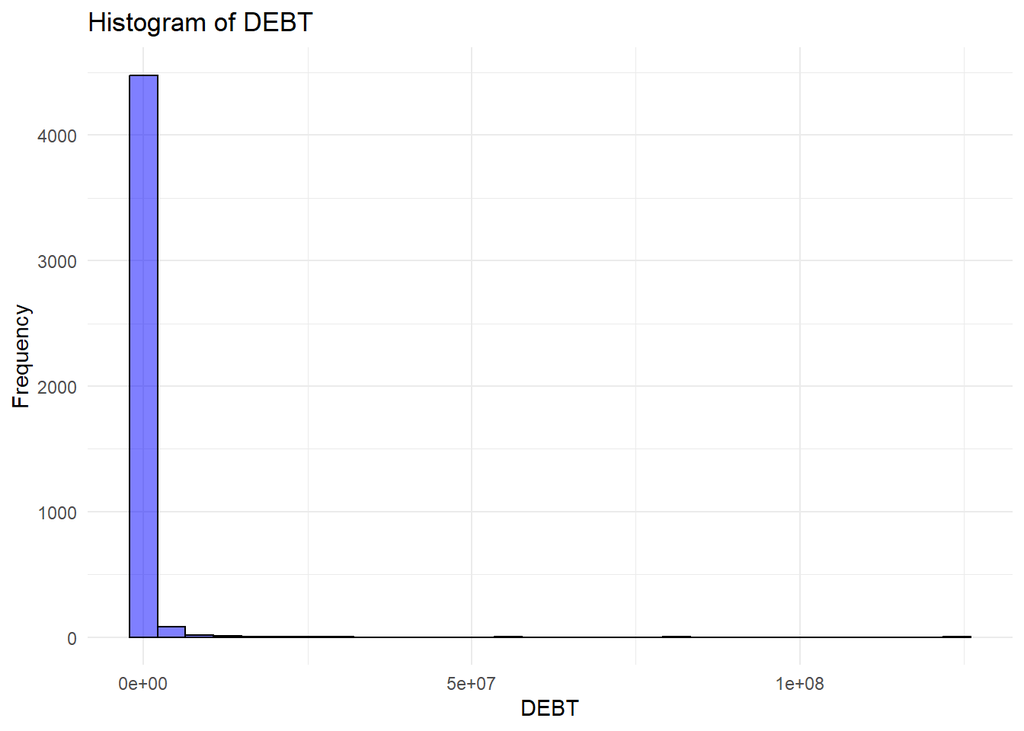

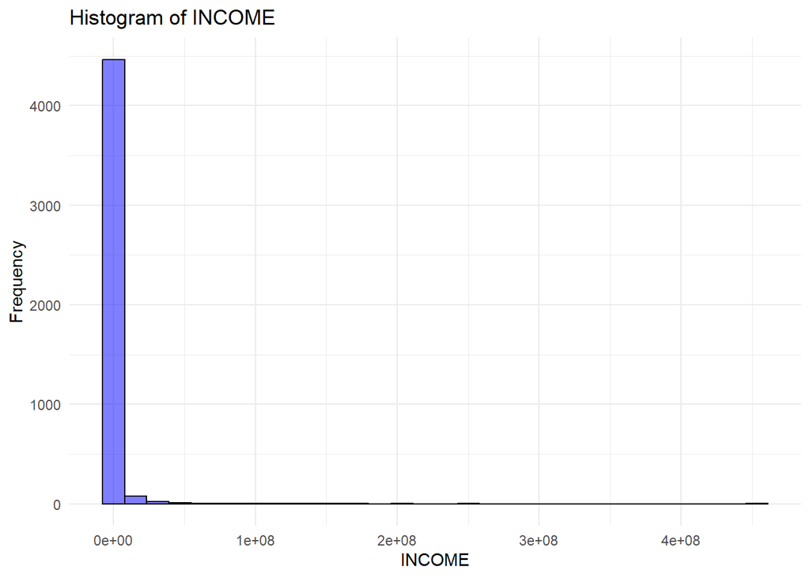

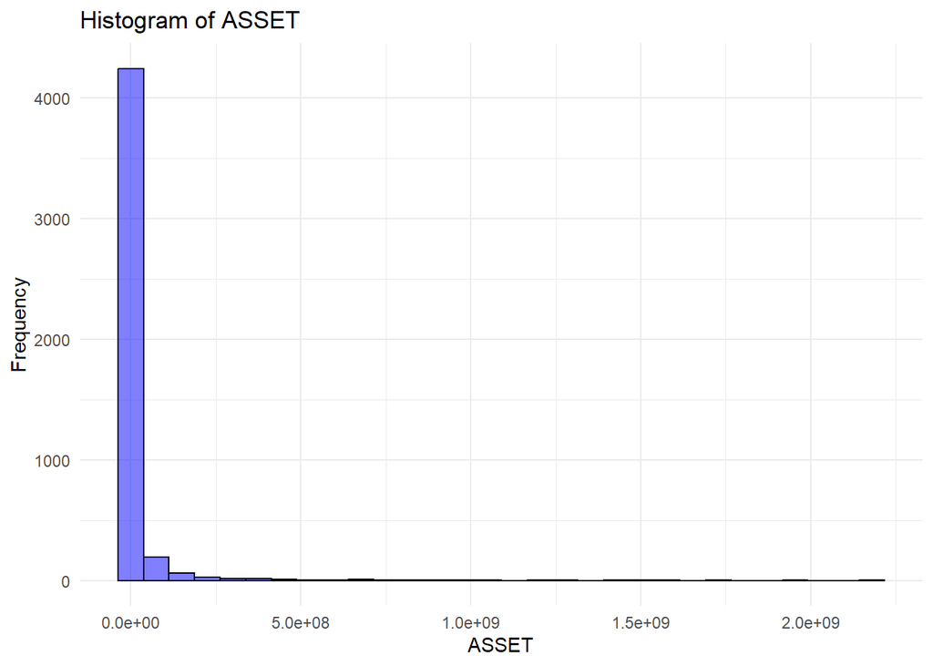

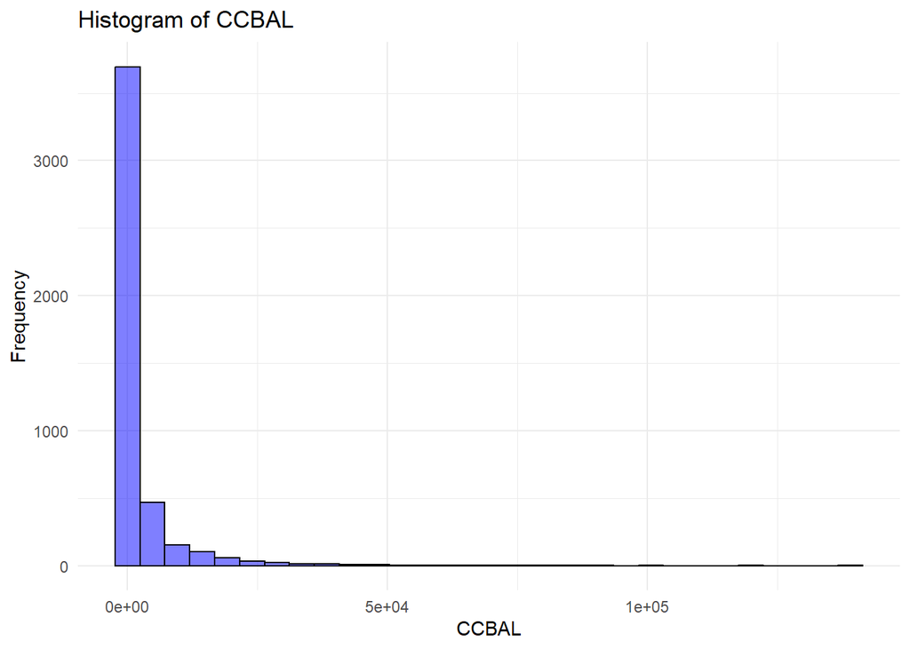

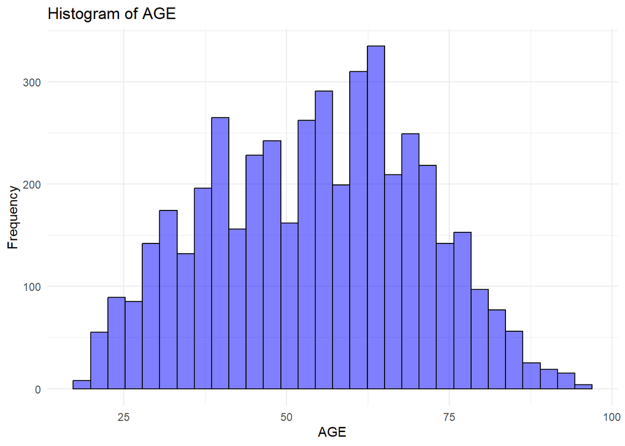

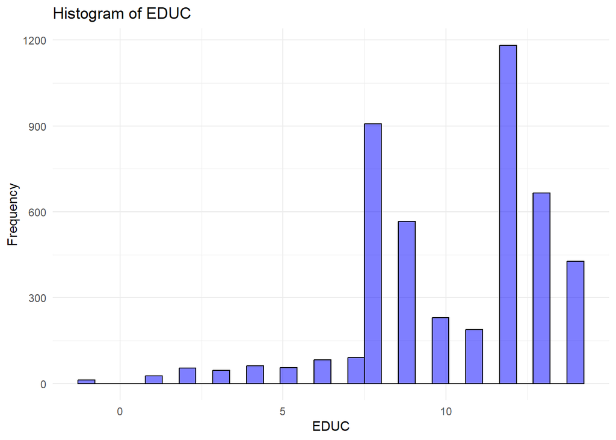

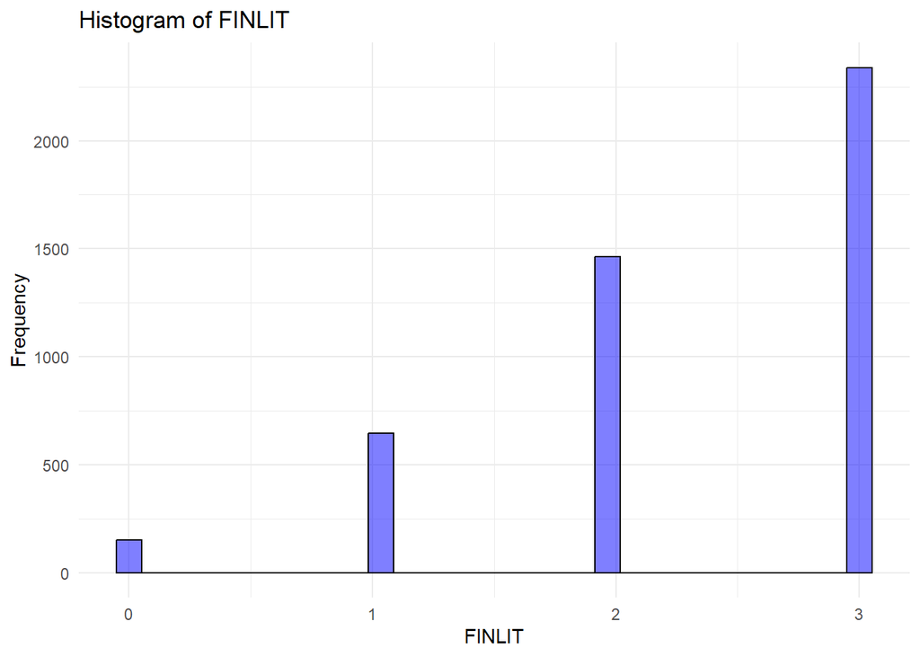

```r
# Create histograms for each numerical variable
for (var in num_vars) {
  print(
    ggplot(data1, aes_string(x = var)) +
      geom_histogram(bins = 30, fill = "blue", alpha = 0.5, color = "black") +
      labs(title = paste("Histogram of", var), x = var, y = "Frequency") +
      theme_minimal()
  )
}
```

From the above we see that “DEBT”, “INCOME”, “ASSET”, “CCBAL” are highly skewed to the right.

Applying log transform to these features to have the data approximate a normal distribution:

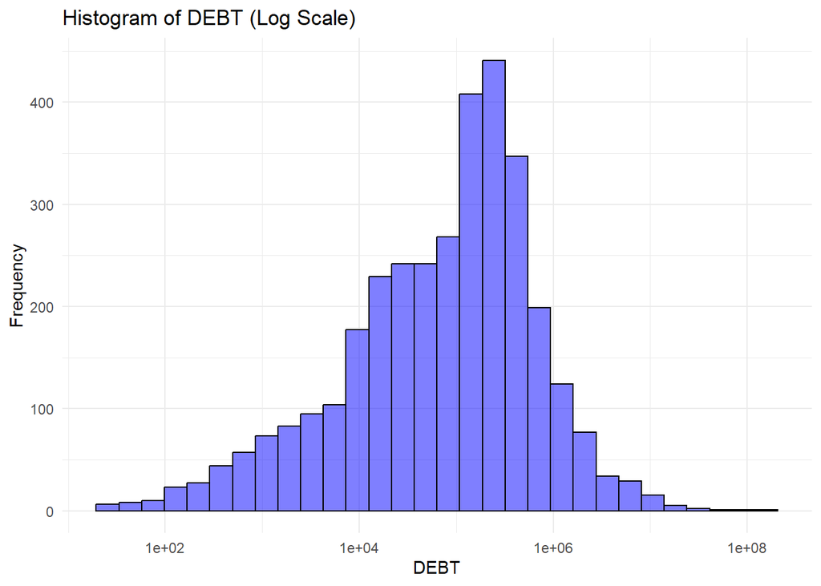

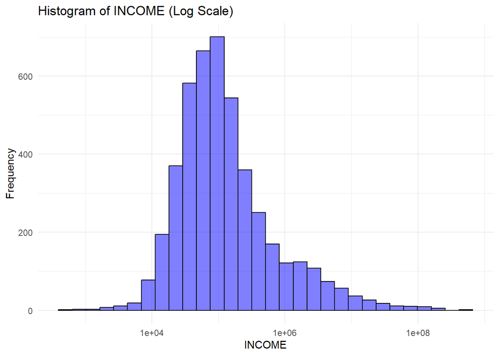

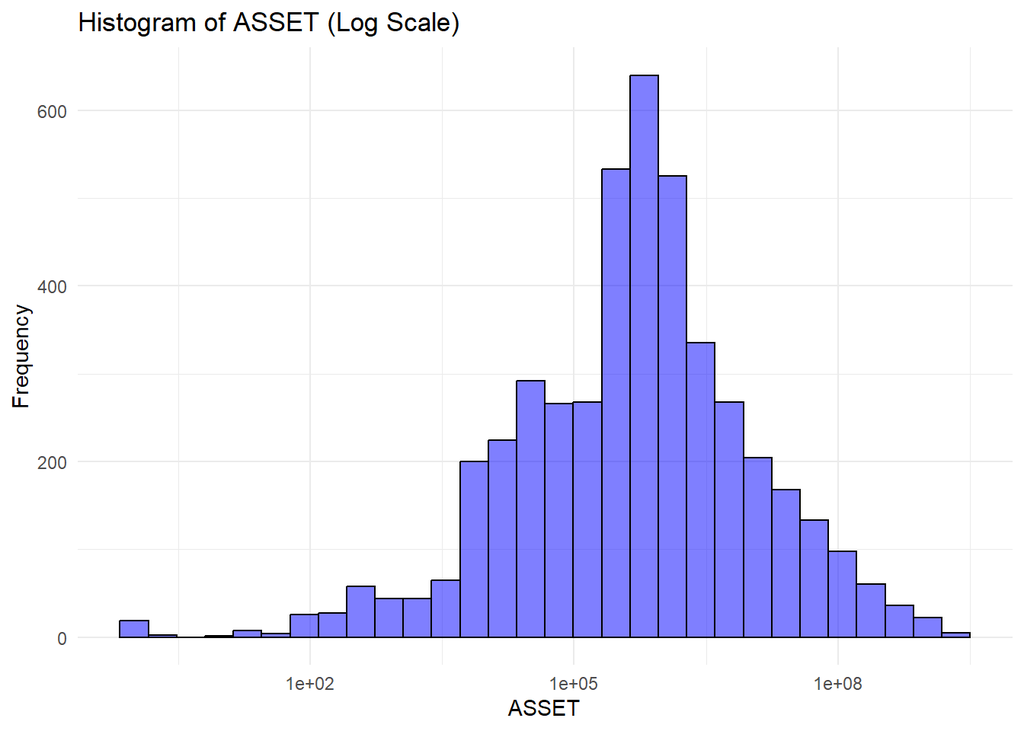

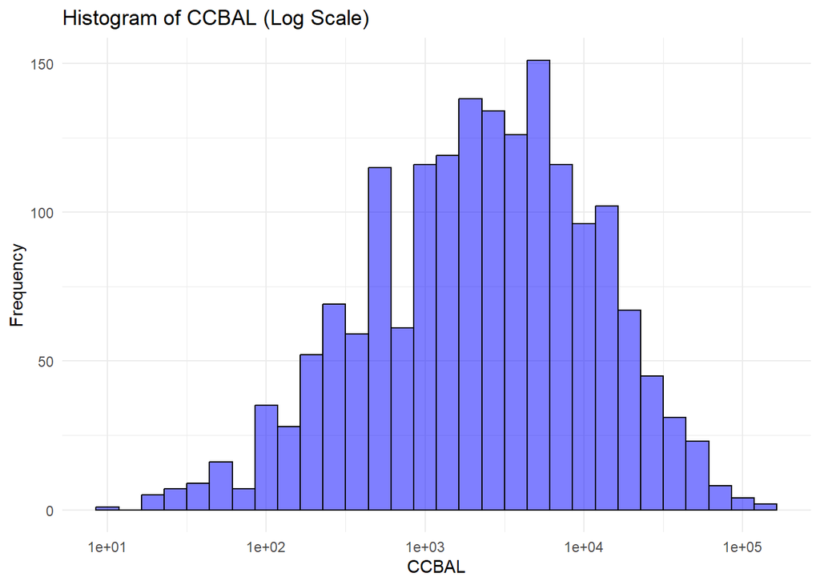

```r
# Define numerical variables
log_vars = c("DEBT", "INCOME", "ASSET", "CCBAL")

# Loop through each variable and plot histogram on log scale
for (var in log_vars) {
  print(
    ggplot(data1, aes_string(x = var)) +
      geom_histogram(bins = 30, fill = "blue", alpha = 0.5, color = "black") +
      scale_x_log10() +  # Log transformation on X-axis
      labs(title = paste("Histogram of", var, "(Log Scale)"), x = var, y = "Frequency") +
      theme_minimal()
  )
}
```

From the DEBT histogram, most debtors owe within 10,000 to 1,000,000  
From the INCOME histogram, a sizable amount of persons earn 6 figure salaries.  
Most Credit Card Balance (CCBAL) falls within 1000 and 10,000

## Visualization of Key Relationships

### Debt vs Income

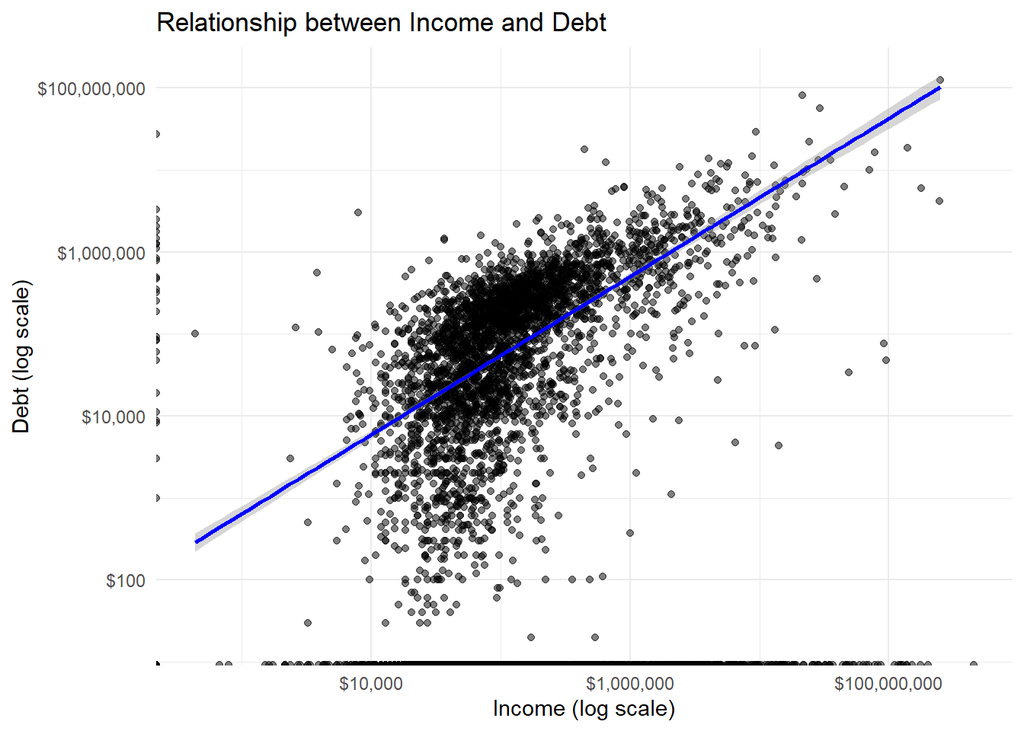

```r
# 1. Debt vs Income
ggplot(data1, aes(x = INCOME, y = DEBT)) +
  geom_point(alpha = 0.5) +
  geom_smooth(method = "lm", color = "blue") +
  scale_x_log10(labels = scales::dollar_format()) +
  scale_y_log10(labels = scales::dollar_format()) +
  labs(title = "Relationship between Income and Debt",
       x = "Income (log scale)",
       y = "Debt (log scale)") +
  theme_minimal()
```

Above figure shows a strong positive relationship between income and debt.

### Debt Distribution by age groups

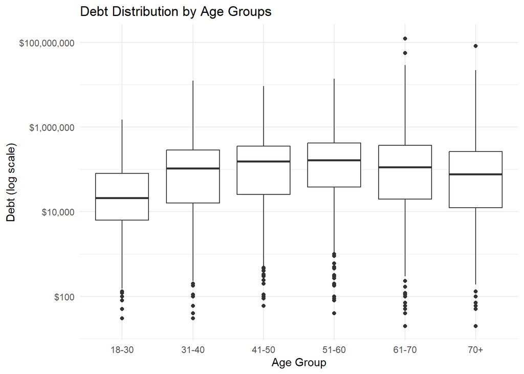

```r
# 2. Debt Distribution by Age Groups
data1$AGE_GROUP = cut(data1$AGE,
                     breaks = c(0, 30, 40, 50, 60, 70, Inf),
                     labels = c("18-30", "31-40", "41-50", "51-60", "61-70", "70+"))

ggplot(data1, aes(x = AGE_GROUP, y = DEBT)) +
  geom_boxplot() +
  scale_y_log10(labels = scales::dollar_format()) +
  labs(title = "Debt Distribution by Age Groups",
       x = "Age Group",
       y = "Debt (log scale)") +
  theme_minimal()
```

### Debt by Education Level

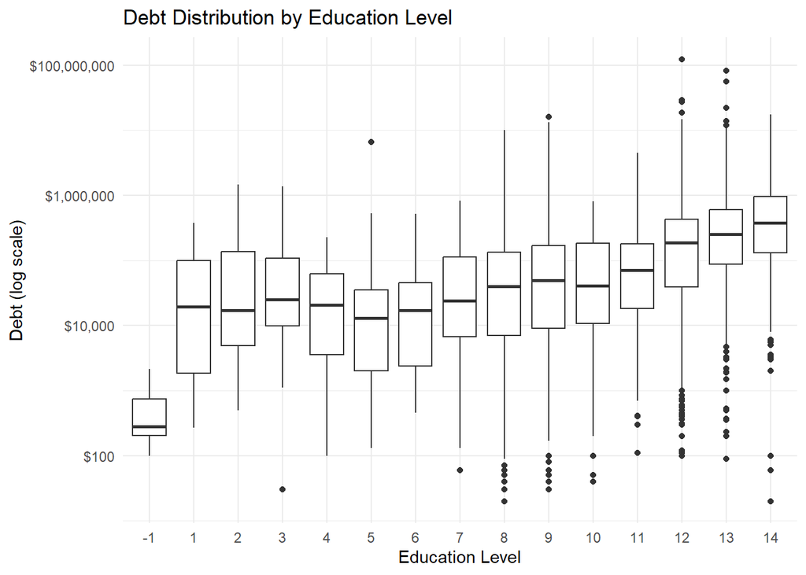

```r
# 3. Debt by Education Level
ggplot(data1, aes(x = as.factor(EDUC), y = DEBT)) +
  geom_boxplot() +
  scale_y_log10(labels = scales::dollar_format()) +
  labs(title = "Debt Distribution by Education Level",
       x = "Education Level",
       y = "Debt (log scale)") +
  theme_minimal()
```

Individuals with higher education levels tend to have higher median debt. This may be attributed to factors such as student loans, mortgages, and increased borrowing capacity associated with higher income potential.

## Correlation Analysis

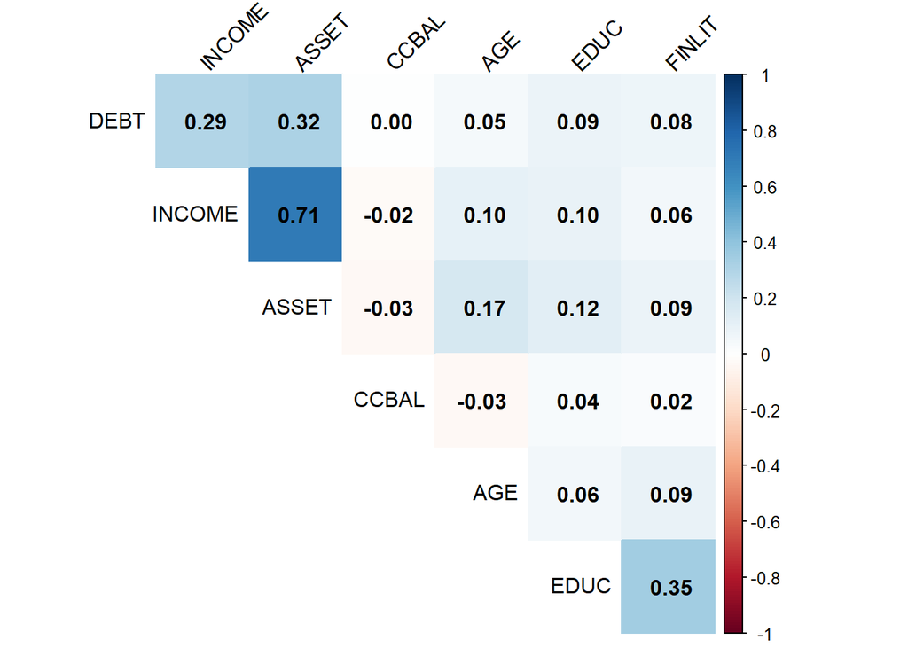

```r
# Select numerical variables for correlation analysis
cor_vars = c("DEBT", "INCOME", "ASSET", "CCBAL", "AGE", "EDUC", "FINLIT")
cor_matrix = cor(data1[cor_vars], use = "complete.obs")

# Create correlation plot
corrplot(cor_matrix,
         method = "color",
         type = "upper",
         addCoef.col = "black",
         tl.col = "black",
         tl.srt = 45,
         diag = FALSE)
```

The correlation analysis identifies key relationships between financial and demographic variables: • Income and Assets (Strongest Correlation): A strong positive correlation exists between income and assets, indicating that individuals with higher income levels tend to accumulate more assets.  
• Financial Literacy and Education: A positive correlation suggests that individuals with higher education levels generally have better financial literacy.  
• Debt and Assets: A positive correlation between debt and assets implies that individuals with more assets also tend to carry higher debt, possibly due to mortgages or investment-related borrowing.  
• Debt and Income: A positive correlation indicates that higher-income individuals tend to have higher debt levels, potentially due to greater access to credit and investment opportunities.

# Modeling

## Assumption Checks

### 1. Check for Class Imbalance

for QDA and LDA

```r
# Check distribution of DEBT_CLASS
table(data1$DEBT_CLASS)
```

```
##
##  Low High
## 2303 2292
```

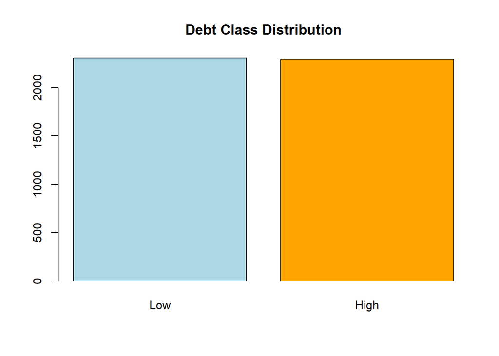

```r
barplot(table(data1$DEBT_CLASS), col=c("lightblue", "orange"), main="Debt Class Distribution")
```

Class is balanced

### 2. Normality Check

**Shapiro-Wilk Test**

LDA & QDA assume normality. Shapiro-Wilk test for univariate normality check.

```r
# Apply Shapiro-Wilk test to all numeric predictors
numeric_vars = c("DEBT", "INCOME", "ASSET", "CCBAL", "AGE", "EDUC", "FINLIT")

#### INCOME, ASSET, CCBAL, AGE, EDUC, FINLIT, MARRIED, HHSEX, LATE, FORECLLAST5, BNKRUPLAST5

normality_results = sapply(data1[numeric_vars], function(x) shapiro.test(x)$p.value)

# Print results
print("Shapiro-Wilk Test for Normality:")
```

```
## [1] "Shapiro-Wilk Test for Normality:"
```

```r
print(normality_results)
```

```
##         DEBT       INCOME        ASSET        CCBAL          AGE         EDUC
## 1.608043e-91 2.785240e-91 2.414443e-89 7.257933e-84 4.921709e-21 5.554486e-48
##       FINLIT
## 1.626484e-62
```

From the above we see that the p-values are less than and alpha of 0.05, thus we reject the null hypothesis and conclude that there is no statistical evidence that the individual variables are normally distributed.

**Multivariate Normality Test**

Henze-Zirkler Test for multivariate normality check.

```r
# Load required libraries
library(MVN)      # For multivariate normality tests
library(MASS)     # For LDA and QDA

hz_test <- mvn(data1[numeric_vars], mvnTest = "hz")
print(hz_test)
```

```
## $multivariateNormality
##            Test    HZ p value MVN
## 1 Henze-Zirkler 18380       0  NO
##
## $univariateNormality
##               Test  Variable Statistic   p value Normality
## 1 Anderson-Darling   DEBT    1355.4290  <0.001      NO
## 2 Anderson-Darling  INCOME   1493.2022  <0.001      NO
## 3 Anderson-Darling   ASSET   1385.5900  <0.001      NO
## 4 Anderson-Darling   CCBAL   1025.0793  <0.001      NO
## 5 Anderson-Darling    AGE      17.2291  <0.001      NO
## 6 Anderson-Darling   EDUC     149.6331  <0.001      NO
## 7 Anderson-Darling  FINLIT    436.3989  <0.001      NO
##
## $Descriptives
##           n         Mean      Std.Dev    Median Min        Max     25th
## DEBT   4595 3.653292e+05 2.630899e+06  29000.00   0  123890000     0.00
## INCOME 4595 1.593197e+06 1.233521e+07  94039.33   0  453258755 42155.56
## ASSET  4595 2.012876e+07 1.098845e+08 542400.00   0 2178241500 62990.00
## CCBAL  4595 2.515314e+03 7.853177e+03      0.00   0     139000     0.00
## AGE    4595 5.446899e+01 1.619049e+01     56.00  18         95    42.00
## EDUC   4595 1.032797e+01 2.816657e+00     11.00  -1         14     8.00
## FINLIT 4595 2.303591e+00 8.293026e-01      3.00   0          3     2.00
##             75th        Skew      Kurtosis
## DEBT    216275.0 32.10007117 1302.74184306
## INCOME  264823.4 19.38179672  519.39178892
## ASSET  2717550.0 10.52135783  135.42865175
## CCBAL     1200.0  6.68276289   65.28864201
## AGE         67.0 -0.06707725   -0.77538874
## EDUC        12.0 -0.92877451    0.87836428
## FINLIT       3.0 -0.95818238    0.05798919
```

From the above, the Anderson-Darling test gave the same outcome as the Shapiro-Wilk test. The Henze-Zirkler multivariate normality test was also not passed.

### 3. Check for Equal Variance

**(Box’s M Test for LDA)**

LDA assumes that different groups have the same variance-covariance structure.

```r
# Run Box's M Test
box_m_test = boxM(data1[numeric_vars], data1$DEBT_CLASS)
print("Box's M Test Results:")
```

```
## [1] "Box's M Test Results:"
```

```r
print(box_m_test)
```

```
##
##  Box's M-test for Homogeneity of Covariance Matrices
##
## data:  data1[numeric_vars]
## Chi-Sq (approx.) = 31172, df = 28, p-value < 2.2e-16
```

With a p-value of 2.2e-16 at an alpha of 0.05, we reject the null hypothesis (that there is equal covariance in each class with respect to the features). Thus, the dataset failed the equal covariance check.

### 4. Multicollinearity Check

**Variance Inflation Factor - VIF***

LDA & QDA require that predictors are not highly correlated.

```r
# Fit a linear model to compute VIF
vif_model <- lm(DEBT ~ ., data = data1[numeric_vars])
alias(vif_model)
```

```
## Model :
## DEBT ~ INCOME + ASSET + CCBAL + AGE + EDUC + FINLIT
```

```r
vif_values <- vif(vif_model)

print("Variance Inflation Factor (VIF) for Predictors:")
```

```
## [1] "Variance Inflation Factor (VIF) for Predictors:"
```

```r
print(vif_values)
```

```
##   INCOME    ASSET    CCBAL      AGE     EDUC   FINLIT
## 1.991648 2.044814 1.003613 1.039754 1.147861 1.144850
```

From the above, the VIF for all the respective variables is less than 5 which implies that multicollinearity is not an issue for the application of LDA and QDA to this dataset. Note that if the VIFs were > 10 for any variable, then multicollinearity would have been an issue with respect to that variable.

## Model Build

### Data Preparation

```r
# Create dataset for modeling
model_data = data1 %>%
  dplyr::select(DEBT_CLASS, INCOME, ASSET, CCBAL, AGE, EDUC, FINLIT, MARRIED, HHSEX, LATE, FORECLLAST5, BNKRUPLAST5) %>%
  na.omit()

# Train-test split
set.seed(123)
train_index = createDataPartition(model_data$DEBT_CLASS, p = 0.7, list = FALSE)
train_data = model_data[train_index, ]
test_data = model_data[-train_index, ]
```

Print summary of the modeling data

```r
summary(train_data)
```

```
##  DEBT_CLASS      INCOME              ASSET               CCBAL
##  Low :1613   Min.   :        0   Min.   :0.000e+00   Min.   :     0
##  High:1605   1st Qu.:    43236   1st Qu.:6.160e+04   1st Qu.:     0
##              Median :    97282   Median :5.731e+05   Median :     0
##              Mean   :  1778711   Mean   :2.158e+07   Mean   :  2583
##              3rd Qu.:   271039   3rd Qu.:2.914e+06   3rd Qu.:  1200
##              Max.   :453258755   Max.   :2.178e+09   Max.   :139000
##       AGE             EDUC           FINLIT         MARRIED
##  Min.   :19.00   Min.   :-1.00   Min.   :0.000   Min.   :1.000
##  1st Qu.:41.00   1st Qu.: 8.00   1st Qu.:2.000   1st Qu.:1.000
##  Median :56.00   Median :11.00   Median :3.000   Median :1.000
##  Mean   :54.52   Mean   :10.34   Mean   :2.314   Mean   :1.367
##  3rd Qu.:67.00   3rd Qu.:12.00   3rd Qu.:3.000   3rd Qu.:2.000
##  Max.   :95.00   Max.   :14.00   Max.   :3.000   Max.   :2.000
##      HHSEX            LATE         FORECLLAST5        BNKRUPLAST5
##  Min.   :1.000   Min.   :0.0000   Min.   :0.000000   Min.   :0.0000
##  1st Qu.:1.000   1st Qu.:0.0000   1st Qu.:0.000000   1st Qu.:0.0000
##  Median :1.000   Median :0.0000   Median :0.000000   Median :0.0000
##  Mean   :1.236   Mean   :0.1128   Mean   :0.004351   Mean   :0.0115
##  3rd Qu.:1.000   3rd Qu.:0.0000   3rd Qu.:0.000000   3rd Qu.:0.0000
##  Max.   :2.000   Max.   :1.0000   Max.   :1.000000   Max.   :1.0000
```

### 1. Linear Discriminant Analysis (LDA)

```r
# Train LDA model
lda_model = lda(DEBT_CLASS ~ ., data = train_data)

# Make predictions on test set
lda_pred = predict(lda_model, test_data)
lda_class = lda_pred$class

# Calculate accuracy
lda_conf_matrix = table(Predicted = lda_class, Actual = test_data$DEBT_CLASS)
lda_accuracy = sum(diag(lda_conf_matrix))/sum(lda_conf_matrix)

# Print results
print("LDA Model Performance:")
```

```
## [1] "LDA Model Performance:"
```

```r
print(lda_conf_matrix)
```

```
##          Actual
## Predicted Low High
##      Low  447  218
##      High 243  469
```

```r
print(paste("LDA Accuracy:", round(lda_accuracy, 3)))
```

```
## [1] "LDA Accuracy: 0.665"
```

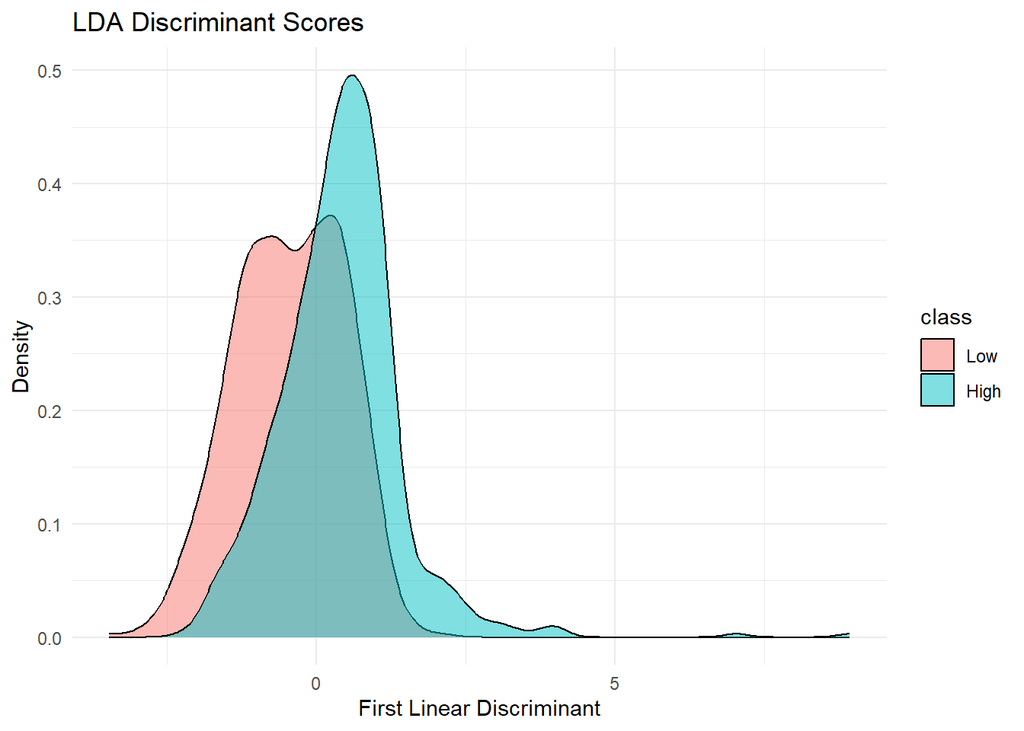

```r
# Plot LDA discriminant scores
lda_data = data.frame(
  score = lda_pred$x,
  class = test_data$DEBT_CLASS
)

ggplot(lda_data, aes(x = LD1, fill = class)) +
  geom_density(alpha = 0.5) +
  labs(title = "LDA Discriminant Scores",
       x = "First Linear Discriminant",
       y = "Density") +
  theme_minimal()
```

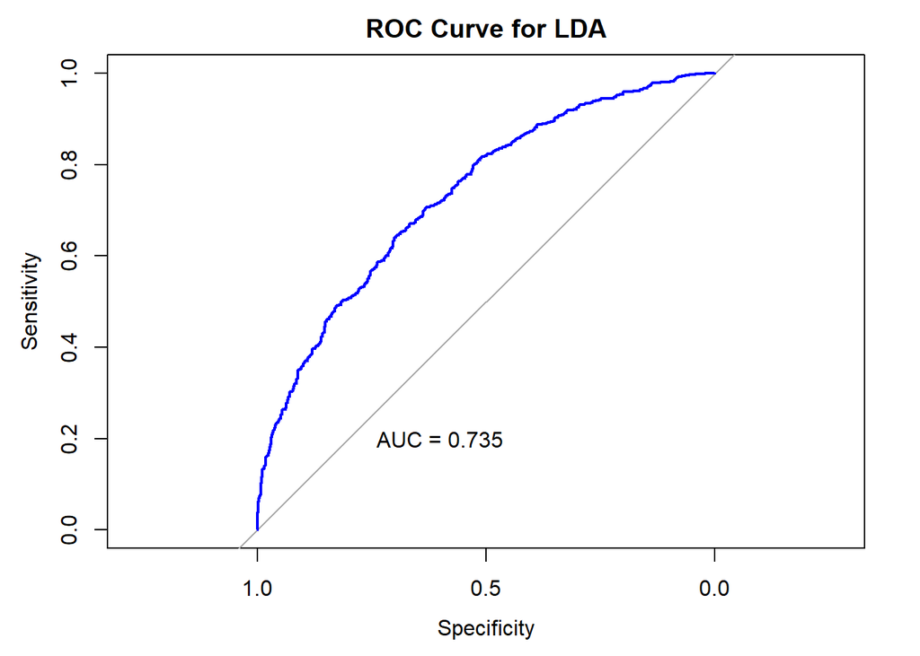

```r
# Calculate and plot ROC curve for LDA
lda_roc = roc(test_data$DEBT_CLASS, lda_pred$posterior[,2])
plot(lda_roc, main = "ROC Curve for LDA",
     col = "blue", lwd = 2)
text(0.6, 0.2, paste("AUC =", round(auc(lda_roc), 3)))
```

**Feature Importance Analysis for LDA**

```r
# Extract absolute LDA coefficients
lda_importance = apply(abs(lda_model$scaling), 1, sum)
lda_importance_df = data.frame(
  Variable = names(lda_importance),
  Importance = lda_importance
) %>%
  arrange(desc(Importance))

# Print top predictors
print("Top Predictors in LDA Model:")
```

```
## [1] "Top Predictors in LDA Model:"
```

```r
print(head(lda_importance_df, 10))
```

```
##                Variable   Importance
## FORECLLAST5 FORECLLAST5 1.702475e+00
## MARRIED         MARRIED 1.041126e+00
## FINLIT           FINLIT 2.890012e-01
## EDUC               EDUC 1.663839e-01
## LATE               LATE 1.149508e-01
## HHSEX             HHSEX 8.448172e-02
## BNKRUPLAST5 BNKRUPLAST5 3.799977e-02
## AGE                 AGE 1.763390e-02
## CCBAL             CCBAL 6.733378e-05
## INCOME           INCOME 2.876196e-09
```

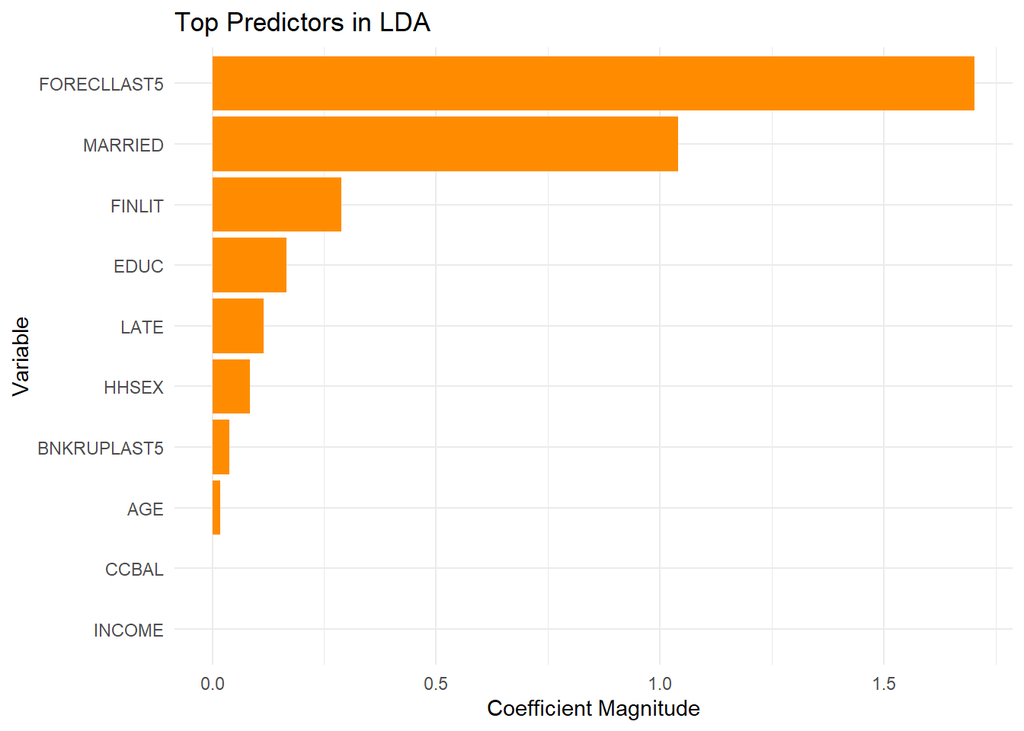

```r
# Visualization
ggplot(head(lda_importance_df, 10), aes(x = reorder(Variable, Importance), y = Importance)) +
  geom_bar(stat="identity", fill="darkorange") +
  coord_flip() +
  labs(title="Top Predictors in LDA", x="Variable", y="Coefficient Magnitude") +
  theme_minimal()
```

### 2. Quadratic Discriminant Analysis (QDA)

```r
# Train QDA model
qda_model = qda(DEBT_CLASS ~ ., data = train_data)

# Make predictions on test set
qda_pred = predict(qda_model, test_data)
qda_class = qda_pred$class

# Calculate accuracy
qda_conf_matrix = table(Predicted = qda_class, Actual = test_data$DEBT_CLASS)
qda_accuracy = sum(diag(qda_conf_matrix))/sum(qda_conf_matrix)

# Print results
print("QDA Model Performance:")
```

```
## [1] "QDA Model Performance:"
```

```r
print(qda_conf_matrix)
```

```
##          Actual
## Predicted Low High
##      Low  534  298
##      High 156  389
```

```r
print(paste("QDA Accuracy:", round(qda_accuracy, 3)))
```

```
## [1] "QDA Accuracy: 0.67"
```

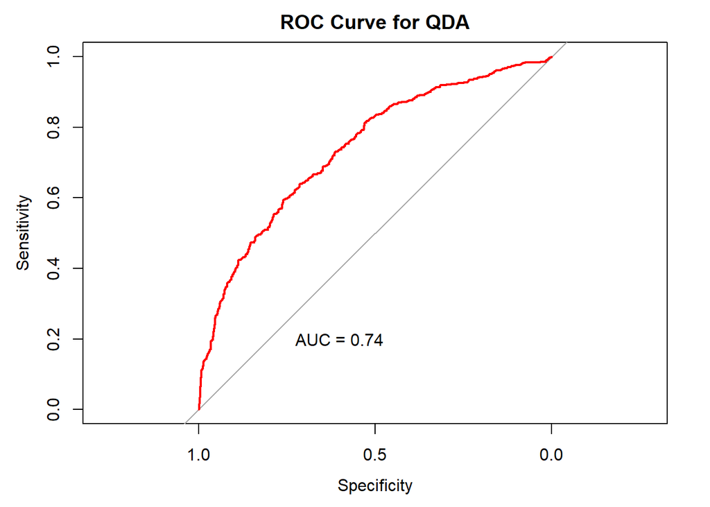

```r
# Calculate and plot ROC curve for QDA
qda_roc = roc(test_data$DEBT_CLASS, qda_pred$posterior[,2])
plot(qda_roc, main = "ROC Curve for QDA",
     col = "red", lwd = 2)
text(0.6, 0.2, paste("AUC =", round(auc(qda_roc), 3)))
```

**Feature Importance for QDA**

```r
# Compute absolute differences in class means for each variable
qda_importance = abs(qda_model$means[1, ] - qda_model$means[2, ])
qda_importance_df = data.frame(
  Variable = names(qda_importance),
  Importance = qda_importance
) %>%
  arrange(desc(Importance))

# Print top predictors
print("Top Predictors in QDA Model:")
```

```
## [1] "Top Predictors in QDA Model:"
```

```r
print(head(qda_importance_df, 10))
```

```
##                Variable   Importance
## ASSET             ASSET 8.903877e+06
## INCOME           INCOME 7.616284e+05
## CCBAL             CCBAL 3.581546e+03
## AGE                 AGE 3.292038e+00
## EDUC               EDUC 1.341038e+00
## FINLIT           FINLIT 3.042333e-01
## MARRIED         MARRIED 2.374558e-01
## HHSEX             HHSEX 1.554457e-01
## LATE               LATE 1.621985e-02
## BNKRUPLAST5 BNKRUPLAST5 3.050371e-03
```

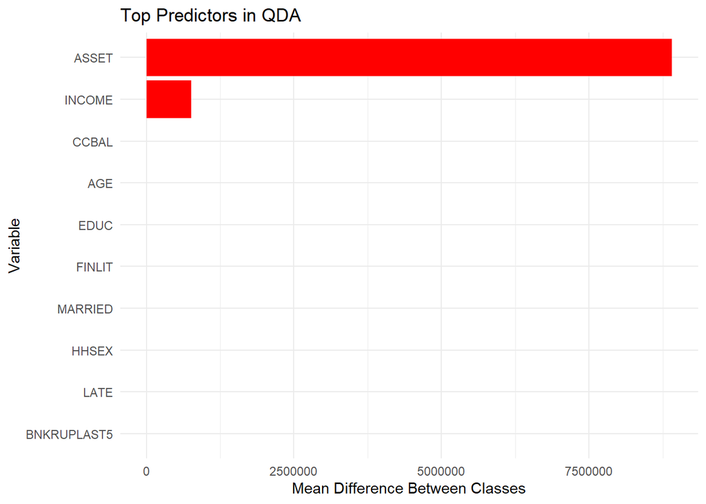

```r
# Visualization
ggplot(head(qda_importance_df, 10), aes(x = reorder(Variable, Importance), y = Importance)) +
  geom_bar(stat="identity", fill="red") +
  coord_flip() +
  labs(title="Top Predictors in QDA", x="Variable", y="Mean Difference Between Classes") +
  theme_minimal()
```

### 3. Random Forest

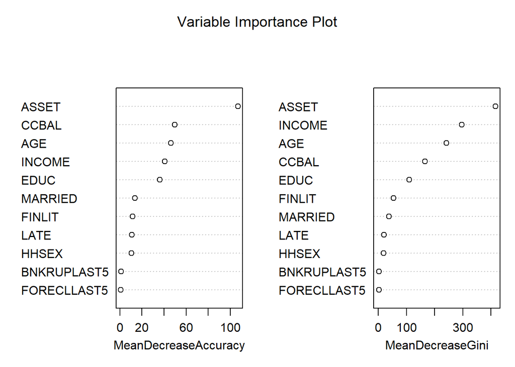

```r
# Load necessary libraries
library(randomForest)
library(pROC)  # For AUC calculation

# Train Random Forest model
rf_model = randomForest(DEBT_CLASS ~ .,
                        data = train_data,
                        ntree = 500,
                        importance = TRUE)

# Variable importance plot
varImpPlot(rf_model,
           main = "Variable Importance Plot",
           sort = TRUE)
```

```r
# Make predictions on test set
rf_pred = predict(rf_model, test_data)

# Calculate accuracy
conf_matrix = table(Predicted = rf_pred, Actual = test_data$DEBT_CLASS)
accuracy_rf = sum(diag(conf_matrix)) / sum(conf_matrix)

# Print Accuracy Results
print("Random Forest Model Performance:")
```

```
## [1] "Random Forest Model Performance:"
```

```r
print(conf_matrix)
```

```
##          Actual
## Predicted Low High
##      Low  526  179
##      High 164  508
```

```r
print(paste("Accuracy:", round(accuracy_rf, 3)))
```

```
## [1] "Accuracy: 0.751"
```

```r
# -------------------------------------------
# **AUC Calculation**
# -------------------------------------------

# Get class probabilities
rf_prob = predict(rf_model, test_data, type = "prob")

# Ensure DEBT_CLASS is a factor
test_data$DEBT_CLASS = as.factor(test_data$DEBT_CLASS)

# Compute AUC using pROC
roc_curve = roc(test_data$DEBT_CLASS, rf_prob[,2])  # Assuming second column is the positive class probability

# Print AUC value
auc_value = auc(roc_curve)
print(paste("AUC:", round(auc_value, 3)))
```

```
## [1] "AUC: 0.836"
```

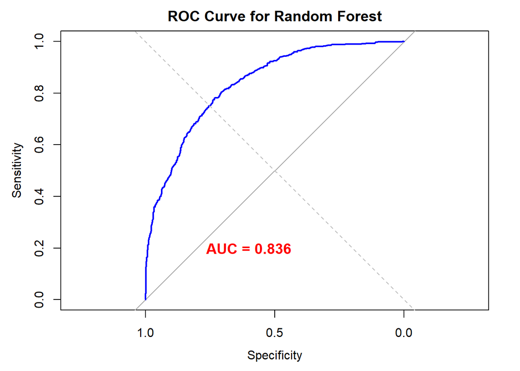

```r
# -------------------------------------------
# **Plot ROC Curve with AUC Displayed**
# -------------------------------------------
plot(roc_curve, col = "blue", lwd = 2, main = "ROC Curve for Random Forest")
abline(a = 0, b = 1, lty = 2, col = "gray")  # Diagonal reference line

# Add AUC value as text on the plot
text(0.6, 0.2, paste("AUC =", round(auc_value, 3)), col = "red", cex = 1.2, font = 2)
```

**Variable Importance**

```r
# Compute variable importance
rf_importance = importance(rf_model)
rf_importance_df = data.frame(
  Variable = rownames(rf_importance),
  Importance = rf_importance[, 1]
) %>%
  arrange(desc(Importance))

# Print top predictors
print("Top Predictors in Random Forest Model:")
```

```
## [1] "Top Predictors in Random Forest Model:"
```

```r
print(head(rf_importance_df, 10))
```

```
##                Variable Importance
## ASSET             ASSET  58.955263
## AGE                 AGE  41.966503
## CCBAL             CCBAL  34.995114
## EDUC               EDUC  28.943611
## INCOME           INCOME  19.208939
## BNKRUPLAST5 BNKRUPLAST5   1.505202
## FINLIT           FINLIT  -1.594824
## HHSEX             HHSEX  -2.409227
## FORECLLAST5 FORECLLAST5  -2.677497
## MARRIED         MARRIED  -4.197497
```

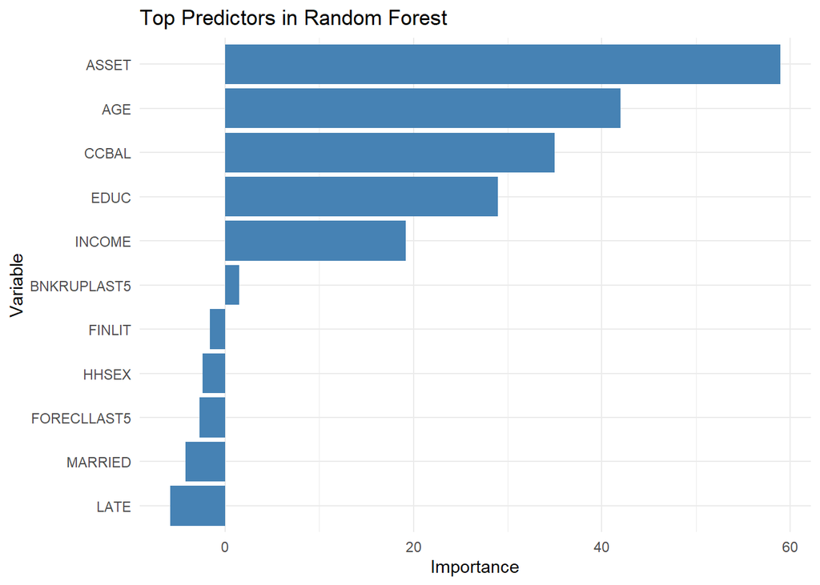

```r
# Visualization
ggplot(head(rf_importance_df, 11), aes(x = reorder(Variable, Importance), y = Importance)) +
  geom_bar(stat="identity", fill="steelblue") +
  coord_flip() +
  labs(title="Top Predictors in Random Forest", x="Variable", y="Importance") +
  theme_minimal()
```

## Model Comparison

```r
model_results <- data.frame(
  Model = c("Random Forest", "LDA", "QDA"),
  Accuracy = c(accuracy_rf, lda_accuracy, qda_accuracy)
)

print("Model Performance Comparison:")
```

```
## [1] "Model Performance Comparison:"
```

```r
print(model_results)
```

```
##           Model  Accuracy
## 1 Random Forest 0.7509078
## 2           LDA 0.6652142
## 3           QDA 0.6702977
```

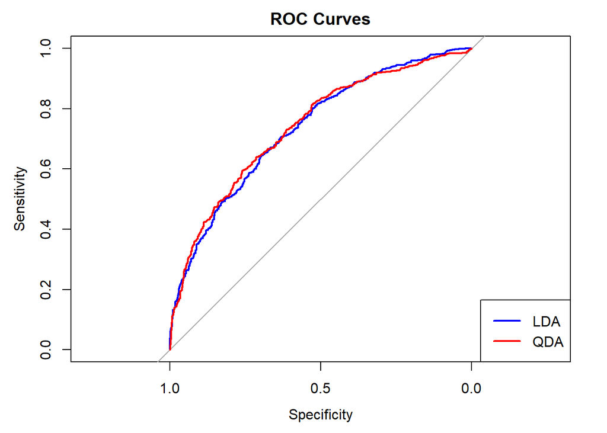

```r
# ROC Curves
lda_roc = roc(test_data$DEBT_CLASS, lda_pred$posterior[,2])
qda_roc = roc(test_data$DEBT_CLASS, qda_pred$posterior[,2])

plot(lda_roc, col = "blue", lwd = 2, main="ROC Curves")
plot(qda_roc, col = "red", lwd = 2, add = TRUE)
legend("bottomright", legend = c("LDA", "QDA"), col = c("blue", "red"), lwd = 2)
```